# Markdown, Knitr, and Slidify

state-of-the-art report/presentation generation in R

## @kohske

### Easy, fun, and beautiful

```
txt <- rep(c("E", "a", "s", "y"), 10)
grid.text(txt, 0.5 + sin(2 * pi * seq_along(txt)/length(txt))/2.2,
    0.5 + cos(2 * pi * seq_along(txt)/length(txt))/2.2, gp = gpar(fontsize = 30,
        col = rainbow(length(txt))))
```

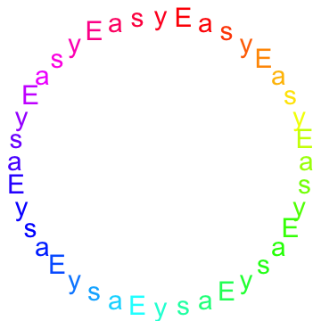

### Reproducible

#### Freedom from

- Hand working
- Copy and paste
- Tweaking graphics by hand

#### All you need is

- Data
- Code
- Text
- Picture

### Tools

All tools are available for free.

- [R](http://www.r-project.org/): environment for data analysis
- [knitr](http://yihui.name/knitr/): report generation tool for R
- [slidify](http://ramnathv.github.com/slidify/): HTML5 slide generator
- [Rstudio](http://rstudio.org/): excellent support for knitr.

[figure not shown]

### Step-by-step tutorial

1. Prepare data
2. Write a code for data analysis
3. Write a code for summary output
4. Write a code for visualization
5. Knit them
6. Publish

### 1. Prepare data

Ok, use `iris`.

```
head(iris)
```

```
##   Sepal.Length Sepal.Width Petal.Length Petal.Width Species
## 1          5.1         3.5          1.4         0.2  setosa
## 2          4.9         3.0          1.4         0.2  setosa
## 3          4.7         3.2          1.3         0.2  setosa
## 4          4.6         3.1          1.5         0.2  setosa
## 5          5.0         3.6          1.4         0.2  setosa
## 6          5.4         3.9          1.7         0.4  setosa
```

Of course, you may use data from your own experiment.

### 2. Write a code for data analysis

summary of `iris`

```
summary(iris)
```

```
##   Sepal.Length   Sepal.Width    Petal.Length   Petal.Width
##  Min.   :4.30   Min.   :2.00   Min.   :1.00   Min.   :0.1
##  1st Qu.:5.10   1st Qu.:2.80   1st Qu.:1.60   1st Qu.:0.3
##  Median :5.80   Median :3.00   Median :4.35   Median :1.3
##  Mean   :5.84   Mean   :3.06   Mean   :3.76   Mean   :1.2
##  3rd Qu.:6.40   3rd Qu.:3.30   3rd Qu.:5.10   3rd Qu.:1.8
##  Max.   :7.90   Max.   :4.40   Max.   :6.90   Max.   :2.5
##        Species
##  setosa    :50
##  versicolor:50
##  virginica :50
##
##
##
```

### 2. Write a code for data analysis

Old-fashioned statistical test.

```
library(reshape2)
library(plyr)
iris2 <- melt(iris)
dlply(iris2, .(variable), function(x) pairwise.t.test(x$value,
    x$Species))
```

```
## $Sepal.Length
##
##  Pairwise comparisons using t tests with pooled SD
##
## data:  x$value and x$Species
##
##            setosa  versicolor
## versicolor 1.8e-15 -
## virginica  < 2e-16 2.8e-09
##
## P value adjustment method: holm
##
## $Sepal.Width
##
##  Pairwise comparisons using t tests with pooled SD
##
## data:  x$value and x$Species
##
##            setosa  versicolor
## versicolor < 2e-16 -
## virginica  9.1e-10 0.0031
##
## P value adjustment method: holm
##
## $Petal.Length
##
##  Pairwise comparisons using t tests with pooled SD
##
## data:  x$value and x$Species
##
##            setosa versicolor
## versicolor <2e-16 -
## virginica  <2e-16 <2e-16
##
## P value adjustment method: holm
##
## $Petal.Width
##
##  Pairwise comparisons using t tests with pooled SD
##
## data:  x$value and x$Species
##
##            setosa versicolor
## versicolor <2e-16 -
## virginica  <2e-16 <2e-16
##
## P value adjustment method: holm
##
## attr(,"split_type")
## [1] "data.frame"
## attr(,"split_labels")
##       variable
## 1 Sepal.Length
## 2  Sepal.Width
## 3 Petal.Length
## 4  Petal.Width
```

### 3. Write a code for summary output.

- For presentation, figures are better
- For report, [static html](http://kohske.github.com/sandbox/slidify/why-slidify/whyslidify_static.html) version with detailed information may be better

### 4. Visualization

```
library(ggplot2)
ggplot(iris2, aes(variable, value, colour = Species)) +
    geom_boxplot() + theme_grey(base_size = 24)
```

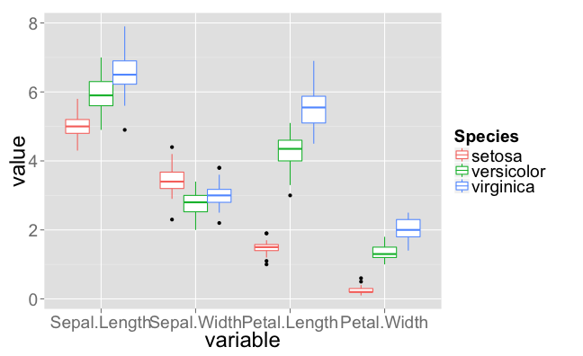

### 5. Markdown

You can knit text, codes, and pictures in a [markdown](http://daringfireball.net/projects/markdown/) file.

Here is the [markdown file](http://kohske.github.com/sandbox/slidify/why-slidify/whyslidify.Rmd) that [generates](http://kohske.github.com/sandbox/slidify/why-slidify/generator.R) this slide.

Then, all you need is:

- generate html

```
knit2html("whyslidify.Rmd")
```

- generate HTML5 slide

```
slidify("whyslidify.Rmd")
```

### 6. Publish

- Upload the html and relevant files.
- Let your boss or your client know the url.

### How to install

```
install.packages("devtools")
library(devtools)
install_github("slidify", "ramnathv")
install_github("knitr", "yihui")
install_github("whisker", "edwindj")
install_github("markdown", "rstudio")
```

- [Rstudio](http://rstudio.org/) supports knitr.
- It also provides a space for publication of knitted report, [Rpubs](http://www.rpubs.com/).